# 04. Dialogues on Democracy: Measures (Factor Analysis, Correlations and Reliability)

Shaye

2026-10-28

# Overview & Measurement Strategy

### Preregistered Dependent Variables

- **Primary DV (Version 1):** Election denialism, measured by participants’ beliefs that fraud changed the outcome of the 2020 US Presidential election (Question 1; `ER0Norm`).
- **Primary DV (Version 2):** Responses to 7 closed-ended questions about beliefs about election legitimacy administered pre- and post-manipulation. Items with a correlation coefficient $> .80$, both pre and post, will be standardized and averaged to form this denialism score, and all other scale items will be treated separately:
  1. *How likely do you think it is that fraud changed the outcome of the 2020 US Presidential election?* (`ER0Norm` / `ElecRigged_Pre_1`)
  2. *How often do you think these illegal practices occur in US elections generally?*
     1. Voters pretending to be someone else (`ElecRigged_1_Pre_1` / `Post_1`)
     2. Casting a ballot more than once (`ElecRigged_1_Pre_2` / `Post_2`)
     3. People voting who are not U.S. citizens (`ElecRigged_1_Pre_3` / `Post_3`)
  3. *To what extent do you agree with the following statements?*
     1. The 2020 presidential election was the result of voter fraud (`ElecRigged_2_Pre_1` / `Post_1`)
     2. The 2020 presidential election was held in a free and fair manner (`ElecRigged_2_Pre_2` / `Post_2`)
     3. Votes will be counted fairly in the upcoming 2024 Presidential elections (`ElecRigged_2_Pre_3` / `Post_3`)
- **Secondary DV:** Person-specific election conspiracy belief confidence on the participant’s stated claim (`Sureness_Pre_1` / `Sureness_Post_1`).

### How Final Measures Are Grouped & Why

- **Primary DV 1: 2020 Election Denialism (`ER0Norm`):** Single-item 0–100 slider asking whether fraud changed the 2020 election outcome (Question 1). Kept separate as the focal preregistered outcome.
- **Primary DV 2: General Denialism Composite (`ER1` / `ER1Norm`):** Averages the 3 general illegal practices items (Question 2a–c: impersonation, double-voting, non-citizen voting). This was the **only** subscale meeting the preregistered $> .80$ reliability criterion at both pre-test ($\alpha = .84$) and post-test ($\alpha = .89$).
- **2024 Election Doubts (`ER2024`):** Question 3c (confidence in 2024 vote counting). Treated separately per the preregistration because it loads independently on its own factor (Factor 3) and measures forward-looking expectations rather than retrospective 2020 fraud beliefs.
- **2020 Denialism Aggregate (`ER2020`):** Averages Question 1 with Question 3a & 3b (all loading together on Factor 2: retrospective 2020 fraud).
- **Secondary DV: Claim Certainty (`Sureness`):** 0–100% confidence in the participant’s specific open-ended election conspiracy theory. Loads moderately on Factor 2 (2020 Denialism), reflecting that participants’ specific theories are mechanistic explanations of 2020 fraud.
- **Aggregate Denialism Index (`ER`):** 6-item composite (`ER1Norm` + `ER2Norm`) used for robustness checks across the overall election denial battery.

**Psychometric Rationale:** Pairwise item correlations confirm that items measure distinct facets rather than redundant rewordings (all pairwise $r < .80$). Both exploratory factor analysis (EFA) and internal consistency ($\alpha$) show three distinct dimensions—**General Denialism**, **2020 Denialism**, and **2024 Expectations**. Grouping the variables this way honors the preregistered decision rule and reflects the empirical structure of the data.

## 1. Exploratory Factor Analysis & Correlations

```r
set.seed(42)  # fa.parallel() simulates; fa(n.iter = 100) bootstraps

#FA to normalize & weigh vars
df_fa <- as.data.frame(df_both %>%
                         dplyr::select(starts_with("ElecRigged_"),"Sureness_Pre_1","Sureness_Post_1","ER0Norm_Pre","ER0Norm_Post"))
df_fa_pre <- as.data.frame(df_fa %>% dplyr::select(contains("_Pre")))
df_fa_post <- as.data.frame(df_fa %>% dplyr::select(contains("_Post")))
df_fa_change <- as.data.frame(df_both %>%
                                dplyr::select(matches("^ER[0-2].*_Diff$"),"Sureness_Diff"))

df_fa  <- scale(df_fa)
df_fa_pre  <- scale(df_fa_pre)
df_fa_post  <- scale(df_fa_post)
df_fa_change  <- scale(df_fa_change)

#dev.off()

#pre only
    #correlations - from ~.28 to .69
datamatrix_pre <- cor(df_fa_pre,use = "complete.obs")

# Clean, descriptive labels matching survey questions across sections
item_labels <- c(
  ER0Norm_Pre        = "Q1: 2020 Outcome Fraud",
  Sureness_Pre_1     = "Claim Certainty",
  ElecRigged_1_Pre_1 = "Q2a: Voter Impersonation",
  ElecRigged_1_Pre_2 = "Q2b: Multiple Voting",
  ElecRigged_1_Pre_3 = "Q2c: Non-Citizen Voting",
  ElecRigged_2_Pre_1 = "Q3a: 2020 Fraud Result",
  ElecRigged_2_Pre_2 = "Q3b: 2020 Free & Fair [rev]",
  ElecRigged_2_Pre_3 = "Q3c: 2024 Fair Count [rev]"
)

png(here::here("figures", "supplement", "fig-denialism-correlations.png"), width = 11, height = 6.3, units = "in", res = 150)
pairs_data <- df_both %>% dplyr::select(all_of(names(item_labels)))
colnames(pairs_data) <- unname(item_labels)

pairs.panels(
  pairs_data,
  density = FALSE, pch = '.',
  na.rm = TRUE,
  method = "spearman", rug = TRUE,
  hist.col = "#080E5B", hist.border = "#080E5B", line.col = "#080E5B",
  ci.col = "lightgray",
  gap = 0, cex.cor = .5, stars = TRUE,
  smooth = TRUE, ci = TRUE, show.points = TRUE,
  ellipses = FALSE,
  main = "Spearman Correlations")
dev.off()
```

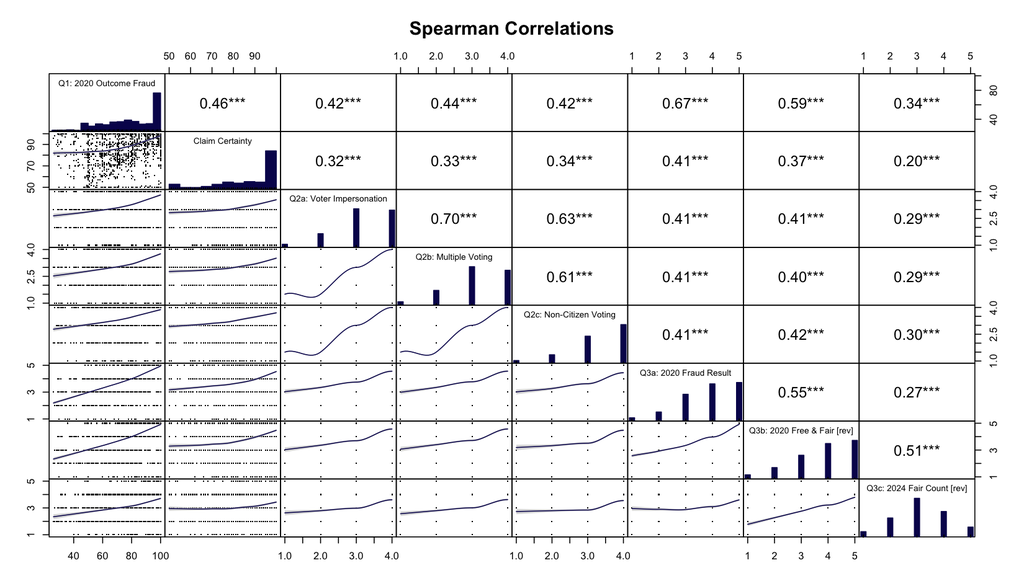

```r
knitr::include_graphics(here::here("figures", "supplement", "fig-denialism-correlations.png"))   # `fig-denialism-correlations`
```

```r
sum(eigen(datamatrix_pre)$values >1) #recs 2 factors
```

```
## [1] 2
```

```r
cortest.bartlett(cor(df_fa_pre),n = 100) #p value <.001 suggests suitability for FA
```

```
## $chisq
## [1] 269.1643
##
## $p.value
## [1] 3.00616e-41
##
## $df
## [1] 28
```

```r
#Compares partial correlation matrix to pairwise correlation matrix. A partial correlation is a correlation after partialing out all other correlations. If the variables are strongly related, partial correlations should be small and MSA close to 1. If MSA > 0.5, data is suitable for factor analysis. https://rpubs.com/zoexoe/592607
KMO(r = cor(df_fa_pre)) #variables strongly correlated
```

```
## Kaiser-Meyer-Olkin factor adequacy
## Call: KMO(r = cor(df_fa_pre))
## Overall MSA =  0.83
## MSA for each item =
## ElecRigged_1_Pre_1 ElecRigged_1_Pre_2 ElecRigged_1_Pre_3 ElecRigged_2_Pre_1
##               0.81               0.82               0.87               0.84
## ElecRigged_2_Pre_2 ElecRigged_2_Pre_3     Sureness_Pre_1        ER0Norm_Pre
##               0.83               0.79               0.91               0.83
```

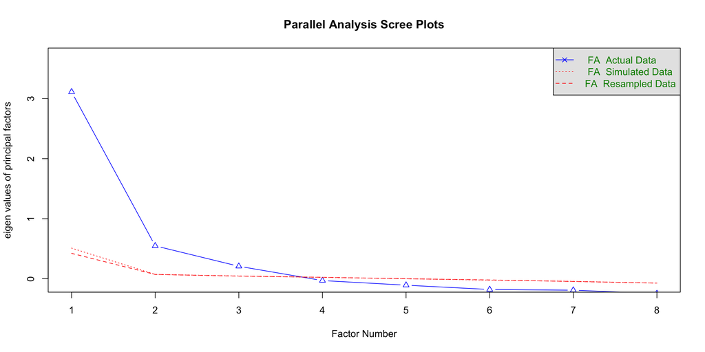

```
## Parallel analysis suggests that the number of factors =  3  and the number of components =  NA
```

```r
    #FA
fa.parallel(df_fa_pre, fa="fa")  #suggests 3 factors
```

```r
  # Perform factor analysis
fa_result_pre <- fa(df_fa_pre, nfactors=3, rotate="promax",n.iter = 100)
fa_result_pre
```

```
## Factor Analysis with confidence intervals using method = fa(r = df_fa_pre, nfactors = 3, n.iter = 100, rotate = "promax")
## Factor Analysis using method =  minres
## Call: fa(r = df_fa_pre, nfactors = 3, n.iter = 100, rotate = "promax")
## Standardized loadings (pattern matrix) based upon correlation matrix
##                      MR1   MR3   MR2   h2     u2 com
## ElecRigged_1_Pre_1  0.89 -0.06 -0.01 0.73 0.2709 1.0
## ElecRigged_1_Pre_2  0.80  0.01  0.00 0.65 0.3467 1.0
## ElecRigged_1_Pre_3  0.70  0.06  0.00 0.56 0.4437 1.0
## ElecRigged_2_Pre_1  0.00  0.75 -0.08 0.50 0.4967 1.0
## ElecRigged_2_Pre_2  0.05  0.44  0.32 0.47 0.5316 1.9
## ElecRigged_2_Pre_3 -0.01 -0.11  1.05 1.00 0.0049 1.0
## Sureness_Pre_1      0.10  0.44 -0.04 0.23 0.7659 1.1
## ER0Norm_Pre        -0.10  0.88  0.00 0.66 0.3362 1.0
##
##                        MR1  MR3  MR2
## SS loadings           1.94 1.68 1.18
## Proportion Var        0.24 0.21 0.15
## Cumulative Var        0.24 0.45 0.60
## Proportion Explained  0.40 0.35 0.25
## Cumulative Proportion 0.40 0.75 1.00
##
##  With factor correlations of
##      MR1  MR3  MR2
## MR1 1.00 0.64 0.39
## MR3 0.64 1.00 0.49
## MR2 0.39 0.49 1.00
##
## Mean item complexity =  1.1
## Test of the hypothesis that 3 factors are sufficient.
##
## df null model =  28  with the objective function =  2.82 with Chi Square =  5195.86
## df of  the model are 7  and the objective function was  0.01
##
## The root mean square of the residuals (RMSR) is  0.01
## The df corrected root mean square of the residuals is  0.02
##
## The harmonic n.obs is  1848 with the empirical chi square  3.46  with prob <  0.84
## The total n.obs was  1848  with Likelihood Chi Square =  14.57  with prob <  0.042
##
## Tucker Lewis Index of factoring reliability =  0.994
```

[output cut: 10 more lines]

```
##                      low   MR1 upper   low   MR3 upper   low   MR2 upper
## ElecRigged_1_Pre_1  0.84  0.89  0.96 -0.11 -0.06 -0.01 -0.04 -0.01  0.03
## ElecRigged_1_Pre_2  0.75  0.80  0.85 -0.03  0.01  0.06 -0.04  0.00  0.04
## ElecRigged_1_Pre_3  0.63  0.70  0.77  0.01  0.06  0.12 -0.05  0.00  0.05
## ElecRigged_2_Pre_1 -0.06  0.00  0.06  0.66  0.75  0.84 -0.19 -0.08 -0.01
## ElecRigged_2_Pre_2 -0.02  0.05  0.09  0.29  0.44  0.52  0.12  0.32  0.66
## ElecRigged_2_Pre_3 -0.04 -0.01  0.03 -0.19 -0.11  0.03  0.71  1.05  1.21
## Sureness_Pre_1      0.04  0.10  0.17  0.35  0.44  0.50 -0.12 -0.04  0.02
## ER0Norm_Pre        -0.16 -0.10 -0.03  0.74  0.88  0.98 -0.04  0.00  0.04
##
##  Interfactor correlations and bootstrapped confidence intervals
##         lower estimate upper
## MR1-MR3  0.60     0.64  0.68
## MR1-MR2  0.30     0.39  0.53
## MR3-MR2  0.41     0.49  0.63
```

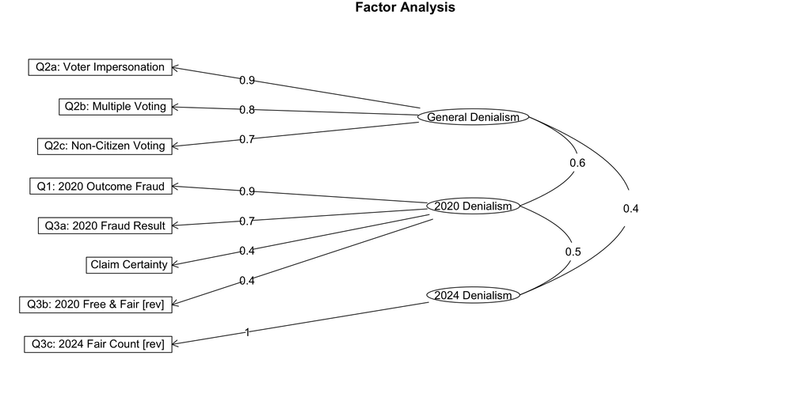

```r
# Assign clean, descriptive labels to loadings matching survey questions and Section 2
rownames(fa_result_pre$loadings) <- unname(item_labels[rownames(fa_result_pre$loadings)])
colnames(fa_result_pre$loadings) <- c("General Denialism", "2020 Denialism", "2024 Denialism")
#dev.off()
# Generate the factor analysis diagram with updated names
psych::fa.diagram(fa_result_pre)
```

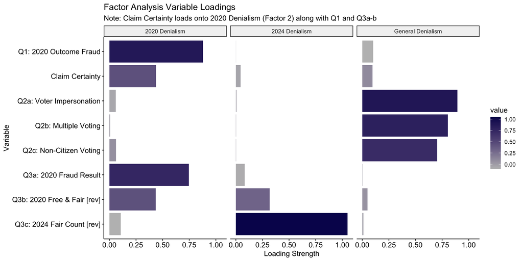

```r
fig_efa <- fa_result_pre$loadings[,] %>%
  as.data.frame() %>%
  tibble::rownames_to_column() %>%
  tidyr::pivot_longer(-rowname) %>%

  ggplot2::ggplot() +
  ggplot2::geom_col(ggplot2::aes(x = abs(value), y = factor(rowname, levels = rev(unname(item_labels))), fill = value)) +  # Reverse y-axis order
  #ggplot2::geom_vline(xintercept = 0.45, color = "gray", linetype = "dashed") +
  ggplot2::facet_grid(cols = dplyr::vars(name)) +
  ggplot2::scale_x_continuous(name = "Loading Strength") +
  ggplot2::scale_y_discrete(name = "Variable") +
  ggplot2::scale_fill_gradient(low = "grey", high = "#080E5B") +  # Custom color gradient
  #ggplot2::geom_text(ggplot2::aes(x = abs(value), y = rowname, label = round(value, 2)), color = "gray", size = 3, vjust = 0, hjust = -1, position = position_dodge(0.9)) +  # Text labels
  theme_pubr() +
  theme(legend.position = "right", legend.title.align = -0) +
  labs(title = "Factor Analysis Variable Loadings",
       subtitle = "Note: Claim Certainty loads onto 2020 Denialism (Factor 2) along with Q1 and Q3a-b")
fig_efa
```

```r
ggsave("figures/supplement/fig-denialism-efa.png", fig_efa, width = 10, height = 5.5, dpi = 300, create.dir = TRUE)   # `fig-denialism-efa`
```

## 2. Reliability & Scale Construction

### 1. Bivariate Correlations across the 7 Items

We test whether any pairwise item correlations meet the preregistered > .80 criterion both pre and post:

```r
# 1. Define all 7 closed-ended items with matching clean labels
items_7_pre <- c(
  "Q1: 2020 Outcome Fraud"      = "ER0Norm_Pre",
  "Q2a: Voter Impersonation"    = "ElecRigged_1_Pre_1",
  "Q2b: Multiple Voting"        = "ElecRigged_1_Pre_2",
  "Q2c: Non-Citizen Voting"     = "ElecRigged_1_Pre_3",
  "Q3a: 2020 Fraud Result"     = "ElecRigged_2_Pre_1",
  "Q3b: 2020 Free & Fair [rev]" = "ElecRigged_2_Pre_2",
  "Q3c: 2024 Fair Count [rev]"  = "ElecRigged_2_Pre_3"
)

items_7_post <- c(
  "Q1: 2020 Outcome Fraud"      = "ER0Norm_Post",
  "Q2a: Voter Impersonation"    = "ElecRigged_1_Post_1",
  "Q2b: Multiple Voting"        = "ElecRigged_1_Post_2",
  "Q2c: Non-Citizen Voting"     = "ElecRigged_1_Post_3",
  "Q3a: 2020 Fraud Result"     = "ElecRigged_2_Post_1",
  "Q3b: 2020 Free & Fair [rev]" = "ElecRigged_2_Post_2",
  "Q3c: 2024 Fair Count [rev]"  = "ElecRigged_2_Post_3"
)

df_7_pre <- df_both %>% dplyr::select(all_of(unname(items_7_pre)))
colnames(df_7_pre) <- names(items_7_pre)

df_7_post <- df_both %>% dplyr::select(all_of(unname(items_7_post)))
colnames(df_7_post) <- names(items_7_post)

cat("--- Pre-Test Pairwise Correlation Matrix (7 Items) ---\n")
```

```
## --- Pre-Test Pairwise Correlation Matrix (7 Items) ---
```

```r
cor_7_pre <- cor(df_7_pre, use = "pairwise.complete.obs")
print(round(cor_7_pre, 2))
```

```
##                             Q1: 2020 Outcome Fraud Q2a: Voter Impersonation
## Q1: 2020 Outcome Fraud                        1.00                     0.37
## Q2a: Voter Impersonation                      0.37                     1.00
## Q2b: Multiple Voting                          0.39                     0.69
## Q2c: Non-Citizen Voting                       0.36                     0.63
## Q3a: 2020 Fraud Result                        0.58                     0.36
## Q3b: 2020 Free & Fair [rev]                   0.50                     0.37
## Q3c: 2024 Fair Count [rev]                    0.32                     0.26
##                             Q2b: Multiple Voting Q2c: Non-Citizen Voting
## Q1: 2020 Outcome Fraud                      0.39                    0.36
## Q2a: Voter Impersonation                    0.69                    0.63
## Q2b: Multiple Voting                        1.00                    0.60
## Q2c: Non-Citizen Voting                     0.60                    1.00
## Q3a: 2020 Fraud Result                      0.37                    0.36
## Q3b: 2020 Free & Fair [rev]                 0.36                    0.37
## Q3c: 2024 Fair Count [rev]                  0.27                    0.26
##                             Q3a: 2020 Fraud Result Q3b: 2020 Free & Fair [rev]
## Q1: 2020 Outcome Fraud                        0.58                        0.50
## Q2a: Voter Impersonation                      0.36                        0.37
## Q2b: Multiple Voting                          0.37                        0.36
## Q2c: Non-Citizen Voting                       0.36                        0.37
## Q3a: 2020 Fraud Result                        1.00                        0.42
## Q3b: 2020 Free & Fair [rev]                   0.42                        1.00
## Q3c: 2024 Fair Count [rev]                    0.22                        0.51
##                             Q3c: 2024 Fair Count [rev]
## Q1: 2020 Outcome Fraud                            0.32
## Q2a: Voter Impersonation                          0.26
## Q2b: Multiple Voting                              0.27
## Q2c: Non-Citizen Voting                           0.26
## Q3a: 2020 Fraud Result                            0.22
## Q3b: 2020 Free & Fair [rev]                       0.51
## Q3c: 2024 Fair Count [rev]                        1.00
```

```r
cat("\n--- Post-Test Pairwise Correlation Matrix (7 Items) ---\n")
```

```
##
## --- Post-Test Pairwise Correlation Matrix (7 Items) ---
```

```r
cor_7_post <- cor(df_7_post, use = "pairwise.complete.obs")
print(round(cor_7_post, 2))
```

```
##                             Q1: 2020 Outcome Fraud Q2a: Voter Impersonation
## Q1: 2020 Outcome Fraud                        1.00                     0.48
## Q2a: Voter Impersonation                      0.48                     1.00
## Q2b: Multiple Voting                          0.49                     0.79
## Q2c: Non-Citizen Voting                       0.45                     0.72
## Q3a: 2020 Fraud Result                        0.60                     0.44
## Q3b: 2020 Free & Fair [rev]                   0.51                     0.35
## Q3c: 2024 Fair Count [rev]                    0.38                     0.30
##                             Q2b: Multiple Voting Q2c: Non-Citizen Voting
## Q1: 2020 Outcome Fraud                      0.49                    0.45
## Q2a: Voter Impersonation                    0.79                    0.72
## Q2b: Multiple Voting                        1.00                    0.69
## Q2c: Non-Citizen Voting                     0.69                    1.00
## Q3a: 2020 Fraud Result                      0.45                    0.44
## Q3b: 2020 Free & Fair [rev]                 0.35                    0.36
## Q3c: 2024 Fair Count [rev]                  0.30                    0.31
##                             Q3a: 2020 Fraud Result Q3b: 2020 Free & Fair [rev]
## Q1: 2020 Outcome Fraud                        0.60                        0.51
## Q2a: Voter Impersonation                      0.44                        0.35
## Q2b: Multiple Voting                          0.45                        0.35
## Q2c: Non-Citizen Voting                       0.44                        0.36
## Q3a: 2020 Fraud Result                        1.00                        0.39
## Q3b: 2020 Free & Fair [rev]                   0.39                        1.00
## Q3c: 2024 Fair Count [rev]                    0.23                        0.62
##                             Q3c: 2024 Fair Count [rev]
## Q1: 2020 Outcome Fraud                            0.38
## Q2a: Voter Impersonation                          0.30
## Q2b: Multiple Voting                              0.30
## Q2c: Non-Citizen Voting                           0.31
## Q3a: 2020 Fraud Result                            0.23
## Q3b: 2020 Free & Fair [rev]                       0.62
## Q3c: 2024 Fair Count [rev]                        1.00
```

```r
# Verify if any off-diagonal correlation exceeds .80 at both pre and post
diag(cor_7_pre) <- 0
diag(cor_7_post) <- 0
pairs_above_80_pre  <- which(cor_7_pre > 0.80, arr.ind = TRUE)
pairs_above_80_post <- which(cor_7_post > 0.80, arr.ind = TRUE)

cat("\nPairs with r > .80 at Pre-Test :", nrow(pairs_above_80_pre) / 2, "\n")
```

```
##
## Pairs with r > .80 at Pre-Test : 0
```

```r
cat("Pairs with r > .80 at Post-Test:", nrow(pairs_above_80_post) / 2, "\n")
```

```
## Pairs with r > .80 at Post-Test: 0
```

```r
cat("Takeaway: No individual item pair reaches r > .80 both pre and post.\n")
```

```
## Takeaway: No individual item pair reaches r > .80 both pre and post.
```

### 2. Scale Internal Consistency & Reliability ($\alpha$)

Testing whether theoretical item sets reach the > .80 reliability benchmark across all multi-item batteries at baseline (Pre) and post-intervention (Post), and reporting test-retest stabilities:

```r
# Helper to convert columns to an unlabelled base data.frame
# (This avoids tibble/labelled method dispatch in psych::alpha which causes bind_rows error)
to_df <- function(df, cols) {
  as.data.frame(lapply(df[, cols, drop = FALSE], as.numeric))
}

calc_scale_alpha <- function(df, cols, check_keys = TRUE) {
  d <- to_df(df, cols)
  a <- suppressWarnings(psych::alpha(d, check.keys = check_keys))
  list(
    raw_alpha = a$total$raw_alpha,
    ci = sprintf("%.2f [%.2f, %.2f]", a$total$raw_alpha, a$feldt$lower.ci, a$feldt$upper.ci),
    obj = a
  )
}

calc_er2020_alpha <- function(df, time = "Pre") {
  if (time == "Pre") {
    d <- data.frame(
      ER0 = df$ER0Norm_Pre,
      Q3a = ((df$ElecRigged_2_Pre_1 - 1) / 4) * 100,
      Q3b = ((df$ElecRigged_2_Pre_2 - 1) / 4) * 100
    )
  } else {
    d <- data.frame(
      ER0 = df$ER0Norm_Post,
      Q3a = ((df$ElecRigged_2_Post_1 - 1) / 4) * 100,
      Q3b = ((df$ElecRigged_2_Post_2 - 1) / 4) * 100
    )
  }
  a <- suppressWarnings(psych::alpha(d, check.keys = TRUE))
  list(
    raw_alpha = a$total$raw_alpha,
    ci = sprintf("%.2f [%.2f, %.2f]", a$total$raw_alpha, a$feldt$lower.ci, a$feldt$upper.ci),
    obj = a
  )
}

calc_er7_alpha <- function(df, time = "Pre") {
  if (time == "Pre") {
    cols <- c("ER0Norm_Pre", "ElecRigged_1_Pre_1", "ElecRigged_1_Pre_2", "ElecRigged_1_Pre_3",
              "ElecRigged_2_Pre_1", "ElecRigged_2_Pre_2", "ElecRigged_2_Pre_3")
  } else {
    cols <- c("ER0Norm_Post", "ElecRigged_1_Post_1", "ElecRigged_1_Post_2", "ElecRigged_1_Post_3",
              "ElecRigged_2_Post_1", "ElecRigged_2_Post_2", "ElecRigged_2_Post_3")
  }
  d <- as.data.frame(scale(to_df(df, cols)))
  a <- suppressWarnings(psych::alpha(d, check.keys = TRUE))
  list(
    raw_alpha = a$total$raw_alpha,
    ci = sprintf("%.2f [%.2f, %.2f]", a$total$raw_alpha, a$feldt$lower.ci, a$feldt$upper.ci),
    obj = a
  )
}

# 1. Subscale: Q2 General Illegal Practices (ElecRigged_1: 3 items)
q2_pre_items  <- c("ElecRigged_1_Pre_1", "ElecRigged_1_Pre_2", "ElecRigged_1_Pre_3")
q2_post_items <- c("ElecRigged_1_Post_1", "ElecRigged_1_Post_2", "ElecRigged_1_Post_3")
alpha_q2_pre  <- calc_scale_alpha(df_both, q2_pre_items)
alpha_q2_post <- calc_scale_alpha(df_both, q2_post_items)

cat("--- Q2 General Denialism Scale (ElecRigged_1: 3 items) Reliability ---\n")
```

```
## --- Q2 General Denialism Scale (ElecRigged_1: 3 items) Reliability ---
```

```r
cat("Pre-Test raw alpha :", round(alpha_q2_pre$raw_alpha, 3), alpha_q2_pre$ci, "(Passes > .80)\n")
```

```
## Pre-Test raw alpha : 0.842 0.84 [0.83, 0.85] (Passes > .80)
```

```r
cat("Post-Test raw alpha:", round(alpha_q2_post$raw_alpha, 3), alpha_q2_post$ci, "(Passes > .80)\n\n")
```

```
## Post-Test raw alpha: 0.892 0.89 [0.88, 0.90] (Passes > .80)
```

```r
# 2. Subscale: Q3 Specific Beliefs (ElecRigged_2: 3 items)
q3_pre_items  <- c("ElecRigged_2_Pre_1", "ElecRigged_2_Pre_2", "ElecRigged_2_Pre_3")
q3_post_items <- c("ElecRigged_2_Post_1", "ElecRigged_2_Post_2", "ElecRigged_2_Post_3")
alpha_q3_pre  <- calc_scale_alpha(df_both, q3_pre_items)
alpha_q3_post <- calc_scale_alpha(df_both, q3_post_items)

cat("--- Q3 Specific Beliefs Scale (ElecRigged_2: 3 items) Reliability ---\n")
```

```
## --- Q3 Specific Beliefs Scale (ElecRigged_2: 3 items) Reliability ---
```

```r
cat("Pre-Test raw alpha :", round(alpha_q3_pre$raw_alpha, 3), alpha_q3_pre$ci, "(Below .80 threshold)\n")
```

```
## Pre-Test raw alpha : 0.651 0.65 [0.62, 0.68] (Below .80 threshold)
```

```r
cat("Post-Test raw alpha:", round(alpha_q3_post$raw_alpha, 3), alpha_q3_post$ci, "(Below .80 threshold)\n\n")
```

```
## Post-Test raw alpha: 0.682 0.68 [0.66, 0.71] (Below .80 threshold)
```

```r
# 3. Subscale: 2020 Denialism Composite (ER2020: 3 items: Q1 + Q3a + Q3b)
alpha_2020_pre  <- calc_er2020_alpha(df_both, "Pre")
```

```
## Number of categories should be increased  in order to count frequencies.
```

```r
alpha_2020_post <- calc_er2020_alpha(df_both, "Post")
```

```
## Number of categories should be increased  in order to count frequencies.
```

```r
cat("--- 2020 Denialism Composite (ER2020: 3 items) Reliability ---\n")
```

```
## --- 2020 Denialism Composite (ER2020: 3 items) Reliability ---
```

```r
cat("Pre-Test raw alpha :", round(alpha_2020_pre$raw_alpha, 3), alpha_2020_pre$ci, "\n")
```

```
## Pre-Test raw alpha : 0.726 0.73 [0.70, 0.75]
```

```r
cat("Post-Test raw alpha:", round(alpha_2020_post$raw_alpha, 3), alpha_2020_post$ci, "\n\n")
```

```
## Post-Test raw alpha: 0.733 0.73 [0.71, 0.75]
```

```r
# 4. 6-Item Denialism Battery (ElecRigged_1 + ElecRigged_2: 6 items)
alpha_6_pre  <- calc_scale_alpha(df_both, c(q2_pre_items, q3_pre_items))
alpha_6_post <- calc_scale_alpha(df_both, c(q2_post_items, q3_post_items))

cat("--- 6-Item Denialism Battery (ER1 + ER2: 6 items) Reliability ---\n")
```

```
## --- 6-Item Denialism Battery (ER1 + ER2: 6 items) Reliability ---
```

```r
cat("Pre-Test raw alpha :", round(alpha_6_pre$raw_alpha, 3), alpha_6_pre$ci, "\n")
```

```
## Pre-Test raw alpha : 0.787 0.79 [0.77, 0.80]
```

```r
cat("Post-Test raw alpha:", round(alpha_6_post$raw_alpha, 3), alpha_6_post$ci, "\n\n")
```

```
## Post-Test raw alpha: 0.816 0.82 [0.80, 0.83]
```

```r
# 5. Omnibus: All 7 Items Standardized (ER: 7 items)
alpha_7_pre  <- calc_er7_alpha(df_both, "Pre")
```

```
## Number of categories should be increased  in order to count frequencies.
```

```r
alpha_7_post <- calc_er7_alpha(df_both, "Post")
```

```
## Number of categories should be increased  in order to count frequencies.
```

```r
cat("--- All 7 Items Combined Reliability (ER: 7 items) ---\n")
```

```
## --- All 7 Items Combined Reliability (ER: 7 items) ---
```

```r
cat("Pre-Test raw alpha :", round(alpha_7_pre$raw_alpha, 3), alpha_7_pre$ci, "(Passes > .80)\n")
```

```
## Pre-Test raw alpha : 0.827 0.83 [0.81, 0.84] (Passes > .80)
```

```r
cat("Post-Test raw alpha:", round(alpha_7_post$raw_alpha, 3), alpha_7_post$ci, "(Passes > .80)\n\n")
```

```
## Post-Test raw alpha: 0.856 0.86 [0.85, 0.87] (Passes > .80)
```

```r
# 6. Institutional Trust (InstTrust: 5 items, Pre only)
items_trust <- c("InstTrust_USGov", "InstTrust_CivilService", "InstTrust_Media", "InstTrust_Banks", "InstTrust_MajorCompanies")
alpha_trust_pre <- calc_scale_alpha(df_both, items_trust)
```

```
## Number of categories should be increased  in order to count frequencies.
```

```r
cat("--- Institutional Trust Scale (InstTrust: 5 items) Reliability ---\n")
```

```
## --- Institutional Trust Scale (InstTrust: 5 items) Reliability ---
```

```r
cat("Pre-Test raw alpha :", round(alpha_trust_pre$raw_alpha, 3), alpha_trust_pre$ci, "(Passes > .80)\n\n")
```

```
## Pre-Test raw alpha : 0.855 0.85 [0.84, 0.86] (Passes > .80)
```

```r
# Build comprehensive summary table across samples:
get_sample_reliabilities <- function(data, sample_label) {
  # ER1
  a_er1_pr <- calc_scale_alpha(data, q2_pre_items)
  a_er1_po <- calc_scale_alpha(data, q2_post_items)
  r_er1    <- cor(data$ER1_Pre, data$ER1_Post, use = "complete.obs")
  dis_er1  <- r_er1 / sqrt(a_er1_pr$raw_alpha * a_er1_po$raw_alpha)

  # ER2
  a_er2_pr <- calc_scale_alpha(data, q3_pre_items)
  a_er2_po <- calc_scale_alpha(data, q3_post_items)
  r_er2    <- cor(data$ER2_Pre, data$ER2_Post, use = "complete.obs")
  dis_er2  <- r_er2 / sqrt(a_er2_pr$raw_alpha * a_er2_po$raw_alpha)

  # ER2020
  a_20_pr  <- calc_er2020_alpha(data, "Pre")
  a_20_po  <- calc_er2020_alpha(data, "Post")
  r_20     <- cor(data$ER2020_Pre, data$ER2020_Post, use = "complete.obs")
  dis_20   <- r_20 / sqrt(a_20_pr$raw_alpha * a_20_po$raw_alpha)

  # ER (7 items)
  a_7_pr   <- calc_er7_alpha(data, "Pre")
  a_7_po   <- calc_er7_alpha(data, "Post")
  r_7      <- cor(data$ER_Pre, data$ER_Post, use = "complete.obs")
  dis_7    <- r_7 / sqrt(a_7_pr$raw_alpha * a_7_po$raw_alpha)

  # Trust
  a_tr     <- calc_scale_alpha(data, items_trust)

  # Single items test-retest r
  r_er0    <- cor(data$ER0Norm_Pre, data$ER0Norm_Post, use = "complete.obs")
  r_sure   <- cor(data$Sureness_Pre_1, data$Sureness_Post_1, use = "complete.obs")
  r_2024   <- cor(data$ER2024_Pre, data$ER2024_Post, use = "complete.obs")
  r_aff    <- cor(data$AffPol_Pre, data$AffPol_Post, use = "complete.obs")

  tibble::tribble(
    ~Measure, ~Items, ~Scale, ~`Pre Alpha [95% CI]`, ~`Post Alpha [95% CI]`, ~`Test-Retest r`, ~`Disattenuated r`,
    "General Election Denialism (ER1)", 3, "1-4", a_er1_pr$ci, a_er1_po$ci, sprintf("%.3f", r_er1), sprintf("%.3f", dis_er1),
    "Specific Election Denial Beliefs (ER2)", 3, "1-5", a_er2_pr$ci, a_er2_po$ci, sprintf("%.3f", r_er2), sprintf("%.3f", dis_er2),
    "2020 Election Denialism Composite (ER2020)", 3, "0-100", a_20_pr$ci, a_20_po$ci, sprintf("%.3f", r_20), sprintf("%.3f", dis_20),
    "Aggregate Election Denialism (ER)", 7, "Standardized", a_7_pr$ci, a_7_po$ci, sprintf("%.3f", r_7), sprintf("%.3f", dis_7),
    "Institutional Trust (InstTrust)", 5, "1-5", a_tr$ci, "—", "—", "—",
    "2020 Election Denialism (ER0Norm, Q1)", 1, "0-100", "— (Single item)", "— (Single item)", sprintf("%.3f", r_er0), "—",
    "Claim Certainty (Sureness, Q2)", 1, "0-100", "— (Single item)", "— (Single item)", sprintf("%.3f", r_sure), "—",
    "2024 Fair Count Expectations (ER2024, Q3c)", 1, "1-5", "— (Single item)", "— (Single item)", sprintf("%.3f", r_2024), "—",
    "Affective Polarization (AffPol)", 2, "0-100", "— (Thermometer Diff)", "— (Thermometer Diff)", sprintf("%.3f", r_aff), "—"
  ) %>% mutate(Sample = sample_label, N = nrow(data))
}

tbl_pooled <- get_sample_reliabilities(df_both, "Pooled Analytic Sample (df_both)")
```

```
## Number of categories should be increased  in order to count frequencies.
## Number of categories should be increased  in order to count frequencies.
## Number of categories should be increased  in order to count frequencies.
## Number of categories should be increased  in order to count frequencies.
## Number of categories should be increased  in order to count frequencies.
```

```r
tbl_s1     <- get_sample_reliabilities(df_consp, "Study 1 (df_consp)")
```

```
## Number of categories should be increased  in order to count frequencies.
## Number of categories should be increased  in order to count frequencies.
## Number of categories should be increased  in order to count frequencies.
## Number of categories should be increased  in order to count frequencies.
## Number of categories should be increased  in order to count frequencies.
```

```r
tbl_s2     <- get_sample_reliabilities(df_consp_2, "Study 2 (df_consp_2)")
```

```
## Number of categories should be increased  in order to count frequencies.
## Number of categories should be increased  in order to count frequencies.
## Number of categories should be increased  in order to count frequencies.
## Number of categories should be increased  in order to count frequencies.
## Number of categories should be increased  in order to count frequencies.
```

```r
cat("### Comprehensive Scale Reliabilities & Test-Retest Stability (Pooled Analytic Sample, N = 1,848)\n")
```

```
## ### Comprehensive Scale Reliabilities & Test-Retest Stability (Pooled Analytic Sample, N = 1,848)
```

```r
knitr::kable(
  tbl_pooled %>% dplyr::select(Measure, Items, Scale, `Pre Alpha [95% CI]`, `Post Alpha [95% CI]`, `Test-Retest r`, `Disattenuated r`),
  caption = "Scale Internal Consistency (Cronbach's alpha) and Stability Across Measures (Pooled Sample, N = 1,848)"
)
```

Scale Internal Consistency (Cronbach’s alpha) and Stability Across Measures (Pooled Sample, N = 1,848)

| Measure | Items | Scale | Pre Alpha [95% CI] | Post Alpha [95% CI] | Test-Retest r | Disattenuated r |
| --- | --- | --- | --- | --- | --- | --- |
| General Election Denialism (ER1) | 3 | 1-4 | 0.84 [0.83, 0.85] | 0.89 [0.88, 0.90] | 0.746 | 0.861 |
| Specific Election Denial Beliefs (ER2) | 3 | 1-5 | 0.65 [0.62, 0.68] | 0.68 [0.66, 0.71] | 0.725 | 1.088 |
| 2020 Election Denialism Composite (ER2020) | 3 | 0-100 | 0.73 [0.70, 0.75] | 0.73 [0.71, 0.75] | 0.728 | 0.998 |
| Aggregate Election Denialism (ER) | 7 | Standardized | 0.83 [0.81, 0.84] | 0.86 [0.85, 0.87] | 0.780 | 0.928 |
| Institutional Trust (InstTrust) | 5 | 1-5 | 0.85 [0.84, 0.86] | — | — | — |
| 2020 Election Denialism (ER0Norm, Q1) | 1 | 0-100 | — (Single item) | — (Single item) | 0.690 | — |
| Claim Certainty (Sureness, Q2) | 1 | 0-100 | — (Single item) | — (Single item) | 0.492 | — |
| 2024 Fair Count Expectations (ER2024, Q3c) | 1 | 1-5 | — (Single item) | — (Single item) | 0.686 | — |
| Affective Polarization (AffPol) | 2 | 0-100 | — (Thermometer Diff) | — (Thermometer Diff) | 0.848 | — |

```r
cat("\n### Scale Reliabilities Breakdown Across Study 1 (n = 1,215) and Study 2 (n = 633)\n")
```

```
##
## ### Scale Reliabilities Breakdown Across Study 1 (n = 1,215) and Study 2 (n = 633)
```

```r
tbl_comparison <- tibble(
  Measure = tbl_pooled$Measure,
  Items = tbl_pooled$Items,
  `Pooled Pre a` = tbl_pooled$`Pre Alpha [95% CI]`,
  `Pooled Post a` = tbl_pooled$`Post Alpha [95% CI]`,
  `Study 1 Pre a` = tbl_s1$`Pre Alpha [95% CI]`,
  `Study 1 Post a` = tbl_s1$`Post Alpha [95% CI]`,
  `Study 2 Pre a` = tbl_s2$`Pre Alpha [95% CI]`,
  `Study 2 Post a` = tbl_s2$`Post Alpha [95% CI]`
)
knitr::kable(tbl_comparison, caption = "Cronbach's Alpha Reliability Comparison Across Studies")
```

Cronbach’s Alpha Reliability Comparison Across Studies

| Measure | Items | Pooled Pre a | Pooled Post a | Study 1 Pre a | Study 1 Post a | Study 2 Pre a | Study 2 Post a |
| --- | --- | --- | --- | --- | --- | --- | --- |
| General Election Denialism (ER1) | 3 | 0.84 [0.83, 0.85] | 0.89 [0.88, 0.90] | 0.84 [0.82, 0.85] | 0.89 [0.88, 0.90] | 0.85 [0.83, 0.87] | 0.89 [0.88, 0.91] |
| Specific Election Denial Beliefs (ER2) | 3 | 0.65 [0.62, 0.68] | 0.68 [0.66, 0.71] | 0.68 [0.64, 0.71] | 0.71 [0.68, 0.74] | 0.59 [0.53, 0.64] | 0.62 [0.56, 0.66] |
| 2020 Election Denialism Composite (ER2020) | 3 | 0.73 [0.70, 0.75] | 0.73 [0.71, 0.75] | 0.77 [0.75, 0.80] | 0.77 [0.75, 0.79] | 0.62 [0.57, 0.67] | 0.64 [0.59, 0.69] |
| Aggregate Election Denialism (ER) | 7 | 0.83 [0.81, 0.84] | 0.86 [0.85, 0.87] | 0.83 [0.82, 0.85] | 0.87 [0.86, 0.88] | 0.82 [0.79, 0.84] | 0.83 [0.81, 0.85] |
| Institutional Trust (InstTrust) | 5 | 0.85 [0.84, 0.86] | — | 0.86 [0.85, 0.87] | — | 0.84 [0.81, 0.86] | — |
| 2020 Election Denialism (ER0Norm, Q1) | 1 | — (Single item) | — (Single item) | — (Single item) | — (Single item) | — (Single item) | — (Single item) |
| Claim Certainty (Sureness, Q2) | 1 | — (Single item) | — (Single item) | — (Single item) | — (Single item) | — (Single item) | — (Single item) |
| 2024 Fair Count Expectations (ER2024, Q3c) | 1 | — (Single item) | — (Single item) | — (Single item) | — (Single item) | — (Single item) | — (Single item) |
| Affective Polarization (AffPol) | 2 | — (Thermometer Diff) | — (Thermometer Diff) | — (Thermometer Diff) | — (Thermometer Diff) | — (Thermometer Diff) | — (Thermometer Diff) |

### 3. Verification of Preregistered Composites from Cleaning Script

The composites were already constructed in `01_cleaning.Rmd`: * **General Denialism (`ER1_Pre` / `ER1_Post`, `ER1Norm`):** Averages the 3 qualifying Q2 items (`ElecRigged_1_1..3`) that surpass the > .80 reliability benchmark both pre and post. * **Aggregate Denialism (`ER_Pre` / `ER_Post`):** The omnibus composite across denialism subscales (averaging `ER1Norm` and `ER2Norm`). * **Separate Measures:** Non-qualifying items (`ER0Norm` for Question 1, `ER2024` for Q3c, etc.) are retained separately as planned.

```r
# Summary of existing composites from 01_cleaning.Rmd
cat("Summary of preregistered composites in df_both (from 01_cleaning.Rmd):\n")
```

```
## Summary of preregistered composites in df_both (from 01_cleaning.Rmd):
```

```r
summary(df_both[, c("ER1_Pre", "ER1_Post",
                    "ER_Pre", "ER_Post",
                    "ER0Norm_Pre", "ER0Norm_Post")])
```

```
##     ER1_Pre         ER1_Post         ER_Pre          ER_Post
##  Min.   :1.000   Min.   :1.000   Min.   :  0.00   Min.   :  0.00
##  1st Qu.:3.000   1st Qu.:2.667   1st Qu.: 55.56   1st Qu.: 52.78
##  Median :3.333   Median :3.000   Median : 70.83   Median : 66.67
##  Mean   :3.218   Mean   :3.119   Mean   : 69.61   Mean   : 66.08
##  3rd Qu.:4.000   3rd Qu.:4.000   3rd Qu.: 84.72   3rd Qu.: 83.33
##  Max.   :4.000   Max.   :4.000   Max.   :100.00   Max.   :100.00
##                  NA's   :189                      NA's   :189
##   ER0Norm_Pre      ER0Norm_Post
##  Min.   : 26.00   Min.   :  0.00
##  1st Qu.: 65.00   1st Qu.: 63.00
##  Median : 80.00   Median : 81.00
##  Mean   : 78.68   Mean   : 77.63
##  3rd Qu.: 99.00   3rd Qu.: 99.00
##  Max.   :100.00   Max.   :100.00
##                   NA's   :189
```

### 4. Test-Retest Stability & Disattenuation Correction

We estimate the true construct stability across time using Spearman’s disattenuation correction:
$$r_{\text{true}}
= \frac{r_{\text{observed}}}{\sqrt{\alpha_{\text{pre}} \times
\alpha_{\text{post}}}}$$

```r
# A. Q2 General Denialism Scale (ElecRigged_1 / ER1: 3 items)
rel_q2_pre  <- alpha_q2_pre$raw_alpha
rel_q2_post <- alpha_q2_post$raw_alpha
obs_r_q2    <- cor(df_both$ER1_Pre, df_both$ER1_Post, use = "complete.obs")
disatt_r_q2 <- obs_r_q2 / sqrt(rel_q2_pre * rel_q2_post)

cat("--- Q2 General Denialism Scale Stability (ER1 / ElecRigged_1) ---\n")
```

```
## --- Q2 General Denialism Scale Stability (ER1 / ElecRigged_1) ---
```

```r
cat("Observed test-retest correlation (attenuated)  :", round(obs_r_q2, 3), "\n")
```

```
## Observed test-retest correlation (attenuated)  : 0.746
```

```r
cat("Disattenuated test-retest correlation (corrected):", round(disatt_r_q2, 3), "\n\n")
```

```
## Disattenuated test-retest correlation (corrected): 0.861
```

```r
# B. Q3 Specific Beliefs Scale (ElecRigged_2 / ER2: 3 items)
rel_q3_pre  <- alpha_q3_pre$raw_alpha
rel_q3_post <- alpha_q3_post$raw_alpha
obs_r_q3    <- cor(df_both$ER2_Pre, df_both$ER2_Post, use = "complete.obs")
disatt_r_q3 <- obs_r_q3 / sqrt(rel_q3_pre * rel_q3_post)

cat("--- Q3 Specific Beliefs Scale Stability (ER2 / ElecRigged_2) ---\n")
```

```
## --- Q3 Specific Beliefs Scale Stability (ER2 / ElecRigged_2) ---
```

```r
cat("Observed test-retest correlation (attenuated)  :", round(obs_r_q3, 3), "\n")
```

```
## Observed test-retest correlation (attenuated)  : 0.725
```

```r
cat("Disattenuated test-retest correlation (corrected):", round(disatt_r_q3, 3), "\n\n")
```

```
## Disattenuated test-retest correlation (corrected): 1.088
```

```r
# C. 2020 Denialism Composite (ER2020: 3 items)
rel_20_pre  <- alpha_2020_pre$raw_alpha
rel_20_post <- alpha_2020_post$raw_alpha
obs_r_20    <- cor(df_both$ER2020_Pre, df_both$ER2020_Post, use = "complete.obs")
disatt_r_20 <- obs_r_20 / sqrt(rel_20_pre * rel_20_post)

cat("--- 2020 Denialism Composite Stability (ER2020: 3 items) ---\n")
```

```
## --- 2020 Denialism Composite Stability (ER2020: 3 items) ---
```

```r
cat("Observed test-retest correlation (attenuated)  :", round(obs_r_20, 3), "\n")
```

```
## Observed test-retest correlation (attenuated)  : 0.728
```

```r
cat("Disattenuated test-retest correlation (corrected):", round(disatt_r_20, 3), "\n\n")
```

```
## Disattenuated test-retest correlation (corrected): 0.998
```

```r
# D. Aggregate Denialism Composite (ER_Pre / ER_Post: 7 items)
rel_7_pre  <- alpha_7_pre$raw_alpha
rel_7_post <- alpha_7_post$raw_alpha
obs_r_agg  <- cor(df_both$ER_Pre, df_both$ER_Post, use = "complete.obs")
disatt_r_agg <- obs_r_agg / sqrt(rel_7_pre * rel_7_post)

cat("--- Aggregate Denialism Composite Stability (ER_Pre / ER_Post) ---\n")
```

```
## --- Aggregate Denialism Composite Stability (ER_Pre / ER_Post) ---
```

```r
cat("Observed test-retest correlation (attenuated)  :", round(obs_r_agg, 3), "\n")
```

```
## Observed test-retest correlation (attenuated)  : 0.78
```

```r
cat("Disattenuated test-retest correlation (corrected):", round(disatt_r_agg, 3), "\n\n")
```

```
## Disattenuated test-retest correlation (corrected): 0.928
```

```r
# E. Single-Item Dependent Variables (Observed Test-Retest Stability)
obs_r_q1 <- cor(df_both$ER0Norm_Pre, df_both$ER0Norm_Post, use = "complete.obs")
obs_r_cc <- cor(df_both$Sureness_Pre_1, df_both$Sureness_Post_1, use = "complete.obs")
obs_r_24 <- cor(df_both$ER2024_Pre, df_both$ER2024_Post, use = "complete.obs")
obs_r_ap <- cor(df_both$AffPol_Pre, df_both$AffPol_Post, use = "complete.obs")

cat("--- Single-Item Dependent Variables & Polarization Stability ---\n")
```

```
## --- Single-Item Dependent Variables & Polarization Stability ---
```

```r
cat("Question 1 (2020 Denialism Slider; ER0Norm)    : r =", round(obs_r_q1, 3), "\n")
```

```
## Question 1 (2020 Denialism Slider; ER0Norm)    : r = 0.69
```

```r
cat("Question 2 (Claim Certainty Slider; Sureness)   : r =", round(obs_r_cc, 3),
    " (in control: r = 0.471; in adv: r = 0.538; in treatment: r = 0.430)\n")
```

```
## Question 2 (Claim Certainty Slider; Sureness)   : r = 0.492  (in control: r = 0.471; in adv: r = 0.538; in treatment: r = 0.430)
```

```r
cat("Question 3c (2024 Fair Count Doubts; ER2024)   : r =", round(obs_r_24, 3), "\n")
```

```
## Question 3c (2024 Fair Count Doubts; ER2024)   : r = 0.686
```

```r
cat("Affective Polarization (Thermometer Diff; AffPol): r =", round(obs_r_ap, 3), "\n")
```

```
## Affective Polarization (Thermometer Diff; AffPol): r = 0.848
```